# WeRateDogs User Preference

### Date:4/12/2020

### Introduction

Dog is a popular pet for people to have. On Twitter, User WeRateDogs rates people's dogs with a humorous comment about the dog. WeRateDogs give out ratings by numerator and denominator. The Numerator would be a scale from 1-10 but sometimes they give numbers such as 13, 14 and 15. The value of denominator is always 10. Reasons why WeRateDogs is a good resource because WeRateDogs has over 4 million followers and has received international media coverage. We can use the data from WeRateDogs to find what kind of dog is more attractive to the people and user preference.

### Popular way to upload tweet

First, I analyze the way people upload their dogs into WeRateDogs. The graph demonstrates the comparison of the number for each source. I observe the majority of the user tweet their dog by iPhone which I can conclude that majority of people taking pictures of their by phone and the majority of people have iPhone. The graph provide us a visualize solution of the question.

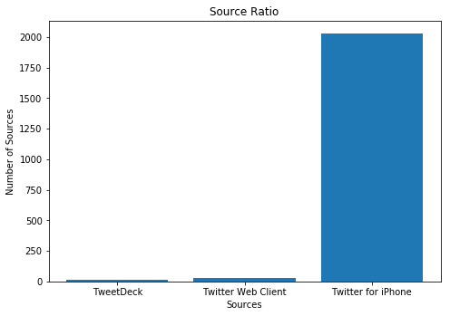

### Favorite tweet and most retweet

I calculate the highest rating by divide the numerator by 10 and The highest rating is 1.5. Twitter id: 838916489579200512 had a rating of 1.5 but the picture that he posts is a picture of a dog from the game. From this, we can conclude this rating sometime is invalid. I found two tweets that one had the highest retweet and the other had the highest favorite. I found the post that had the most retweet is because he posts a funny video and comment on the dog. For the most favorite tweet, as we investing more we can find out why this dog had so many like.

### Name rank for dog

For the last, I create a graph to show the most common name that people naming their dogs. According to the graph, Charlie is the most common name people use to naming their dog. In the dataset, some of the dog have inapporiated such as a, none, and etc. and those name are not consider in this analysis.

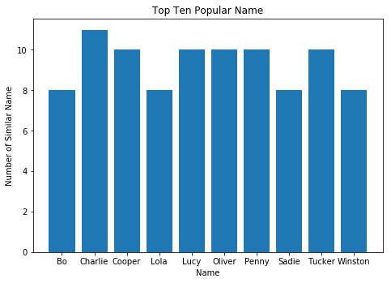

### Conclusion

There is no such a scale to determine a dog is the most adorable or popular. All the dog can be favor in their own way. In the analysis, the most retweet post is not because the dog's appearance but determine by it's action and the person's filming skill. My result only illustrates small group of people who have follow WeRateDog. As the data could be bigger the analysis would be more accurate.

### Author: Yifan Yang